# Project Report - PML Coursera Course

Krishna Sridharan

February 4, 2018

# Objective

To create a model to predict the “classe” variable describing the quality of the exercise based on a series of personal activity measurements

# Datasets

- Training data: 19,622 observations with 160 co-variates/measurement types
- Testing data: 20 observations with 160 co-variates/measurement types

# Analysis

## Data download and reading

The training and testing data was downloaded from the links provided, and read into respective dataframes

```r
library(readr)
pml_training <- suppressWarnings(read_csv("pml-training.csv"))
pml_testing <- suppressWarnings(read_csv("pml-testing.csv"))
```

## Co-variate filtering and QC

Upon viewing the dataframes cursorily, it appeared that a lot of predictors had either NA or a single unique value which would make them potentially useless for prediction of the classe variable  
In order to list these near-zero variance predictors in testing and training the following commands were used:

```r
## Eliminate near Zero covariates
# Identify this is testing and training set
library(caret)
length(colnames(pml_training[nearZeroVar(pml_training)]))   ## This yields 41 columns which are invariate
```

```
## [1] 41
```

```r
length(colnames(pml_testing[nearZeroVar(pml_testing)]))     ## This yields 101 columns which are invariate
```

```
## [1] 101
```

```r
# If only 101-41 columns are gonna be useful when you predict on the data, why bother with calculating 60 extra columns
useless_test_columns = colnames(pml_testing[nearZeroVar(pml_testing)])
useless_test_columns = append(useless_test_columns,c("problem_id","X1"))   ## Because these two columns don't make a difference
pml_testing_clean = data.frame(pml_testing[,!colnames(pml_testing) %in% useless_test_columns])
pml_training_clean = data.frame(pml_training[,!colnames(pml_training) %in% useless_test_columns])
```

Another issue with the data was that there are NA values which might affect the running of models and thus, we need to remove that as part of QC too

```r
pml_testing_clean = na.omit(pml_testing_clean)
pml_training_clean = na.omit(pml_training_clean)
```

## Model training and cross-validation

In order to more accurately choose our model for predicting testing data, we can do k-fold cross-validation on our data to see which predictor does best at training.  
Choosing k was a tricky question but I used resources such as the following to determine that a 10-fold non-repeated Cross Validation would be sufficient for most model-selection:  
* Why k=10 works well? https://stats.stackexchange.com/questions/27730/choice-of-k-in-k-fold-cross-validation  
* Why is non-repeated CV ok? https://www.researchgate.net/post/Repeated_N-fold_cross_validation

Also setting a seed for reproducibility and easier comparison

```r
set.seed(33833)
train_control = trainControl(method="cv", number=10)
```

### Dimensionality reduction and choosing models

Our dataset has 57 predictors which could still be a higher number of predictors than needed. For instance, the testing data has 20 observations but almost 3 times the number of predictors (n=57). Hence, I explored dimensionality reduction using PCA to reduce the number of predictors. In a problem that will benefit from reducing/condensing the predictors, PCA aids some machine learning methods through dimensionality reduction. Alternately, our prediction could also benefit from the increased number of dimensions and predictors, and performance could get affected by PCA.  
In order to understand which classification/prediction models get affected by dimensionality reduction and which others do not, I did some literature review using the following references:  
* A performance comparison of models: http://citeseerx.ist.psu.edu/viewdoc/download?doi=10.1.1.74.8032&rep=rep1&type=pdf

- Another performance comparison with and without PCA: Int. J. of Computers, Communications & Control, ISSN 1841-9836, E-ISSN 1841-9844 Vol. VI (2011), No. 2 (June), pp. 317-327
- A general overview of pros and cons of different ML algorithms: https://elitedatascience.com/machine-learning-algorithms

The two consideration for selecting models were as follows:  
* Choose a model that performed well similar problems in literature  
* Choose a wide variety of models to compare -  
+ Multinomial logistic regression for data that be potentially described by a linear model - Known to benefit from PCA  
+ k-nearest neighbor for potentially simpler cases - Known to benefit from PCA  
+ Gradient boosting tree for classification trees on data with a high number of dimensions + Random Forest for classification trees  
+ Support Vector Machines to model potential non-linearity in the data

```r
## PCA
preproc = preProcess(pml_training_clean,method = c("center","scale","pca"))
transformed_training = predict(preproc,pml_training_clean)

# Penalized multinomial logistic regression with PCA
model_penalized_mlg_pca = train(classe ~ ., data=transformed_training, trControl=train_control, method="multinom")
model_penalized_mlg_pca
```

```
## Penalized Multinomial Regression
##
## 19621 samples
##    30 predictor
##     5 classes: 'A', 'B', 'C', 'D', 'E'
##
## No pre-processing
## Resampling: Cross-Validated (10 fold)
## Summary of sample sizes: 17658, 17659, 17658, 17659, 17659, 17660, ...
## Resampling results across tuning parameters:
##
##   decay  Accuracy   Kappa
##   0e+00  0.8024061  0.7500772
##   1e-04  0.8026100  0.7503147
##   1e-01  0.7984829  0.7451663
##
## Accuracy was used to select the optimal model using the largest value.
## The final value used for the model was decay = 1e-04.
```

```r
getTrainPerf(model_penalized_mlg_pca)
```

```
##   TrainAccuracy TrainKappa   method
## 1       0.80261  0.7503147 multinom
```

```r
# K-nearest neighbors with PCA
model_kknn_pca = train(classe ~ ., data=transformed_training, trControl=train_control, method="kknn")
model_kknn_pca
```

```
## k-Nearest Neighbors
##
## 19621 samples
##    30 predictor
##     5 classes: 'A', 'B', 'C', 'D', 'E'
##
## No pre-processing
## Resampling: Cross-Validated (10 fold)
## Summary of sample sizes: 17658, 17660, 17658, 17661, 17658, 17659, ...
## Resampling results across tuning parameters:
##
##   kmax  Accuracy   Kappa
##   5     0.9948526  0.9934892
##   7     0.9948526  0.9934892
##   9     0.9948526  0.9934892
##
## Tuning parameter 'distance' was held constant at a value of 2
##
## Tuning parameter 'kernel' was held constant at a value of optimal
## Accuracy was used to select the optimal model using the largest value.
## The final values used for the model were kmax = 9, distance = 2 and
##  kernel = optimal.
```

```r
getTrainPerf(model_kknn_pca)
```

```
##   TrainAccuracy TrainKappa method
## 1     0.9948526  0.9934892   kknn
```

```r
# Ensemble methods of regression trees: Gradient Boosting Tree
model_gbm = train(classe ~ ., data=pml_training_clean, trControl=train_control, method="gbm")
model_gbm
```

```
## Stochastic Gradient Boosting
##
## 19621 samples
##    57 predictor
##     5 classes: 'A', 'B', 'C', 'D', 'E'
##
## No pre-processing
## Resampling: Cross-Validated (10 fold)
## Summary of sample sizes: 17659, 17659, 17659, 17661, 17659, 17658, ...
## Resampling results across tuning parameters:
##
##   interaction.depth  n.trees  Accuracy   Kappa
##   1                   50      0.8398122  0.7966758
##   1                  100      0.8985264  0.8714981
##   1                  150      0.9278825  0.9086365
##   2                   50      0.9579026  0.9467051
##   2                  100      0.9874116  0.9840774
##   2                  150      0.9927122  0.9907820
##   3                   50      0.9837928  0.9794977
##   3                  100      0.9941392  0.9925870
##   3                  150      0.9970444  0.9962617
##
## Tuning parameter 'shrinkage' was held constant at a value of 0.1
##
## Tuning parameter 'n.minobsinnode' was held constant at a value of 10
## Accuracy was used to select the optimal model using the largest value.
## The final values used for the model were n.trees = 150,
##  interaction.depth = 3, shrinkage = 0.1 and n.minobsinnode = 10.
```

```r
getTrainPerf(model_gbm)
```

```
##   TrainAccuracy TrainKappa method
## 1     0.9970444  0.9962617    gbm
```

```r
# Ensemble methods of regression trees: Random Forest
model_rf = train(classe ~ ., data=pml_training_clean, trControl=train_control, method="rf")
model_rf
```

```
## Random Forest
##
## 19621 samples
##    57 predictor
##     5 classes: 'A', 'B', 'C', 'D', 'E'
##
## No pre-processing
## Resampling: Cross-Validated (10 fold)
## Summary of sample sizes: 17659, 17658, 17661, 17659, 17660, 17659, ...
## Resampling results across tuning parameters:
##
##   mtry  Accuracy   Kappa
##    2    0.9918455  0.9896839
##   40    0.9994904  0.9993554
##   79    0.9990317  0.9987752
##
## Accuracy was used to select the optimal model using the largest value.
## The final value used for the model was mtry = 40.
```

```r
getTrainPerf(model_rf)
```

```
##   TrainAccuracy TrainKappa method
## 1     0.9994904  0.9993554     rf
```

```r
# Finally, an SVM but non-linear, using RBF (linear SVMs perfomr similar to linear regression)
model_svmRBF = train(classe ~ ., data=pml_training_clean, trControl=train_control, method="svmRadial")
model_svmRBF
```

```
## Support Vector Machines with Radial Basis Function Kernel
##
## 19621 samples
##    57 predictor
##     5 classes: 'A', 'B', 'C', 'D', 'E'
##
## No pre-processing
## Resampling: Cross-Validated (10 fold)
## Summary of sample sizes: 17659, 17661, 17659, 17660, 17660, 17659, ...
## Resampling results across tuning parameters:
##
##   C     Accuracy   Kappa
##   0.25  0.9200358  0.8987167
##   0.50  0.9370084  0.9201616
##   1.00  0.9495461  0.9360735
##
## Tuning parameter 'sigma' was held constant at a value of 0.007799254
## Accuracy was used to select the optimal model using the largest value.
## The final values used for the model were sigma = 0.007799254 and C = 1.
```

```r
getTrainPerf(model_svmRBF)
```

```
##   TrainAccuracy TrainKappa    method
## 1     0.9495461  0.9360735 svmRadial
```

## Comparing models and choosing the best one

```r
results <- resamples(list(PMLG=model_penalized_mlg_pca, KNN=model_kknn_pca, GBM=model_gbm, RF=model_rf, SVMRBF=model_svmRBF))
# summarize the distributions
summary(results)
```

```
##
## Call:
## summary.resamples(object = results)
##
## Models: PMLG, KNN, GBM, RF, SVMRBF
## Number of resamples: 10
##
## Accuracy
##             Min.   1st Qu.    Median      Mean   3rd Qu.      Max. NA's
## PMLG   0.7910296 0.8005351 0.8028528 0.8026100 0.8066285 0.8077511    0
## KNN    0.9933775 0.9938815 0.9946475 0.9948526 0.9954146 0.9974516    0
## GBM    0.9949058 0.9959246 0.9971967 0.9970444 0.9983424 0.9984709    0
## RF     0.9989812 0.9991083 0.9994902 0.9994904 0.9998726 1.0000000    0
## SVMRBF 0.9378502 0.9472948 0.9492864 0.9495461 0.9541175 0.9566548    0
##
## Kappa
##             Min.   1st Qu.    Median      Mean   3rd Qu.      Max. NA's
## PMLG   0.7358795 0.7476676 0.7507687 0.7503147 0.7552980 0.7565363    0
## KNN    0.9916223 0.9922608 0.9932283 0.9934892 0.9942010 0.9967771    0
## GBM    0.9935567 0.9948450 0.9964546 0.9962617 0.9979033 0.9980660    0
## RF     0.9987113 0.9988722 0.9993551 0.9993554 0.9998388 1.0000000    0
## SVMRBF 0.9212066 0.9332438 0.9357517 0.9360735 0.9418817 0.9450856    0
```

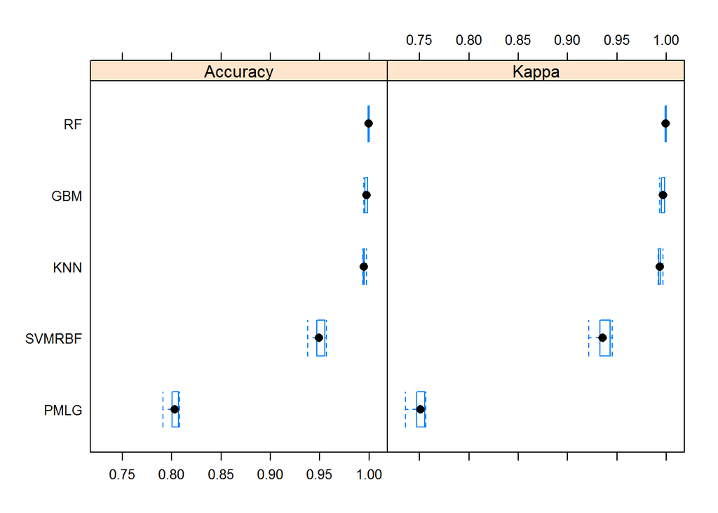

```r
# boxplots of results
bwplot(results)
```

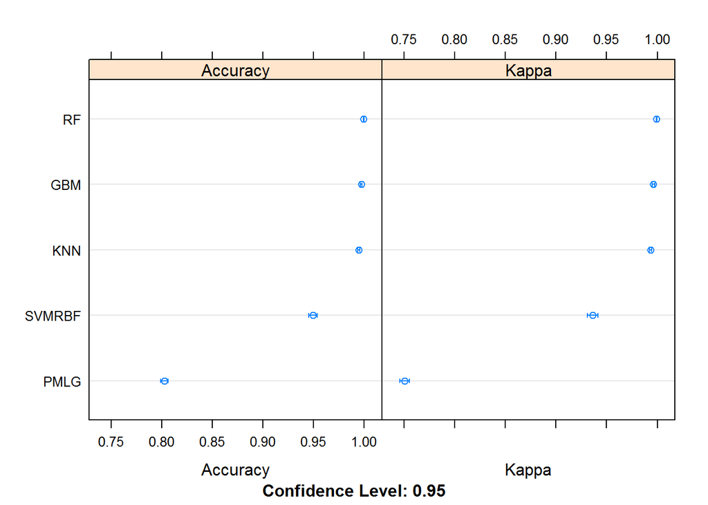

```r
# dot plots of results
dotplot(results)
```

```r
# Final comparison
getTrainPerf(model_rf)
```

```
##   TrainAccuracy TrainKappa method
## 1     0.9994904  0.9993554     rf
```

```r
getTrainPerf(model_gbm)
```

```
##   TrainAccuracy TrainKappa method
## 1     0.9970444  0.9962617    gbm
```

### Estimating the out-of-sample error of the best model

```r
model_rf$finalModel
```

```
##
## Call:
##  randomForest(x = x, y = y, mtry = param$mtry)
##                Type of random forest: classification
##                      Number of trees: 500
## No. of variables tried at each split: 40
##
##         OOB estimate of  error rate: 0.04%
## Confusion matrix:
##      A    B    C    D    E  class.error
## A 5579    0    0    0    0 0.0000000000
## B    1 3795    1    0    0 0.0005267316
## C    0    3 3419    0    0 0.0008766803
## D    0    0    1 3214    1 0.0006218905
## E    0    0    0    0 3607 0.0000000000
```

## Predictions on testing data

```r
predict(model_rf,pml_testing_clean)
```

```
##  [1] B A B A A E D B A A B C B A E E A B B B
## Levels: A B C D E
```